# A8_T1 Pause

Create a menu-driven program which has three options:

1. Set pause duration
2. Activate pause
3. Exit

Utilize `time`-library’s `sleep`-function to implement the pause in the program.

Create a single program file “`A8_T1.py`”. Use this exercise to build the “`template.py`” mentioned earlier.

**Example program runs:**

```
Program starting.
Options:
1 - Set pause duration
2 - Activate pause
0 - Exit
Your choice: 1
Insert pause duration (s): 0.1

Options:
1 - Set pause duration
2 - Activate pause
0 - Exit
Your choice: 2
Pausing for 0.1 seconds.
Unpaused.

Options:
1 - Set pause duration
2 - Activate pause
0 - Exit
Your choice: 0
Exiting program.

Program ending.
```

```
Program starting.
Options:
1 - Set pause duration
2 - Activate pause
0 - Exit
Your choice: 2
Pause is not set.
Set pause first.

Options:
1 - Set pause duration
2 - Activate pause
0 - Exit
Your choice: 1
Insert pause duration (s): 0.05

Options:
1 - Set pause duration
2 - Activate pause
0 - Exit
Your choice: 0
Exiting program.

Program ending.
```

```
Program starting.
Options:
1 - Set pause duration
2 - Activate pause
0 - Exit
Your choice: a
Unknown option!

Options:
1 - Set pause duration
2 - Activate pause
0 - Exit
Your choice: 0
Exiting program.

Program ending.
```

# A8_T2 Calculator

Create a menu-driven program which can perform basic arithmetic operations. All the math operations should be performed with floating datatype and without rounding. Separate the functionality into the appropriate files.

**Recommended subprogram names for the main file:**

- `def main() -> None:`
- `def showOptions() -> None:`
- `def askChoice() -> int:`
- `def askValue(PPrompt: str) -> float:`

**Recommended subprogram names for the library file:**

- `def add(PAddend1: float, PAddend2: float) -> float:`
- `def subtract(PMinuend: float, PSubtrahend: float) -> float:`
- `def multiply(PMultiplicant: float, PMultiplier: float) -> float:`
- `def divide(PDividend: float, PDivisor: float) -> float:`

**Example program runs:**

```
Program starting.
Options:
1 - Add
2 - Subtract
3 - Multiply
4 - Divide
0 - Exit
Your choice: 1
Insert first addend value: 2
Insert second addend value: 3
2.0 + 3.0 = 5.0

Options:
1 - Add
2 - Subtract
3 - Multiply
4 - Divide
0 - Exit
Your choice: 0
Exiting program.

Program ending.
```

```
Program starting.
Options:
1 - Add
2 - Subtract
3 - Multiply
4 - Divide
0 - Exit
Your choice: 2
Insert minuend value: 3
Insert subtrahend value: 6
3.0 - 6.0 = -3.0

Options:
1 - Add
2 - Subtract
3 - Multiply
4 - Divide
0 - Exit
Your choice: 2
Insert minuend value: 5
Insert subtrahend value: 5
5.0 - 5.0 = 0.0

Options:
1 - Add
2 - Subtract
3 - Multiply
4 - Divide
0 - Exit
Your choice: 0
Exiting program.

Program ending.
```

```
Program starting.
Options:
1 - Add
2 - Subtract
3 - Multiply
4 - Divide
0 - Exit
Your choice: 3
Insert multiplicand value: 6
Insert multiplier value: 3
6.0 * 3.0 = 18.0

Options:
1 - Add
2 - Subtract
3 - Multiply
4 - Divide
0 - Exit
Your choice: 0
Exiting program.

Program ending.
```

```
Program starting.
Options:
1 - Add
2 - Subtract
3 - Multiply
4 - Divide
0 - Exit
Your choice: 4
Insert dividend value: 6
Insert divisor value: 3
6.0 / 3.0 = 2.0

Options:
1 - Add
2 - Subtract
3 - Multiply
4 - Divide
0 - Exit
Your choice: 0
Exiting program.

Program ending.
```

# A8_T3 Number files

Create a menu-driven program for analysing number files.

### Datasets

- A8_T3_D1.txt
- A8_T3_D2.txt

**Menu options:**

1. Read values
2. Amount of values
3. Calculate sum of values
4. Calculate average of values

The recommendation during the “`readValues`” operation is to skip the empty rows “`\n`” and convert the rows into floating point values. Values can be stored into a `list[float]` data structure.

The amount of values can be calculated directly by using the “`len`”- function for the values list. For analysing (options 3 and 4), pass the list of values as an argument to some specific function. After calculating the sum or the average, round the results to one decimal precision. E.g. “`1.234`” => “`1.2`”

**Example program runs:**

```
Program starting.
Options:
1 - Read values
2 - Amount of values
3 - Calculate sum of values
4 - Calculate average of values
0 - Exit
Your choice: 1
Insert filename: A8_T3_D1.txt

Options:
1 - Read values
2 - Amount of values
3 - Calculate sum of values
4 - Calculate average of values
0 - Exit
Your choice: 2
Amount of values 5

Options:
1 - Read values
2 - Amount of values
3 - Calculate sum of values
4 - Calculate average of values
0 - Exit
Your choice: 3
Sum of values -115.5

Options:
1 - Read values
2 - Amount of values
3 - Calculate sum of values
4 - Calculate average of values
0 - Exit
Your choice: 4
Average of values -23.1

Options:
1 - Read values
2 - Amount of values
3 - Calculate sum of values
4 - Calculate average of values
0 - Exit
Your choice: 0
Exiting program.

Program ending.
```

```
Program starting.
Options:
1 - Read values
2 - Amount of values
3 - Calculate sum of values
4 - Calculate average of values
0 - Exit
Your choice: 1
Insert filename: A8_T3_D2.txt

Options:
1 - Read values
2 - Amount of values
3 - Calculate sum of values
4 - Calculate average of values
0 - Exit
Your choice: 4
Average of values -18.7

Options:
1 - Read values
2 - Amount of values
3 - Calculate sum of values
4 - Calculate average of values
0 - Exit
Your choice: 3
Sum of values -1874.5

Options:
1 - Read values
2 - Amount of values
3 - Calculate sum of values
4 - Calculate average of values
0 - Exit
Your choice: 2
Amount of values 100

Options:
1 - Read values
2 - Amount of values
3 - Calculate sum of values
4 - Calculate average of values
0 - Exit
Your choice: 0
Exiting program.

Program ending.
```

# A8_T4 Years, Months and Weekdays

Create a menu-driven program which is able to read timestamps and count timestamps based on “year”, “month” or “weekday”. Use both provided datasets: “`A8_T1D1.txt`” and “`A8_T1D2.txt`”.

### Datasets

- A8_T4_D1.txt
- A8_T4_D2.txt

For handling the timestamps use the “`datetime`” library and look for the [datetime library documentation](https://docs.python.org/3/library/datetime.html) aspects:

- strptime and format directives `%Y`, `%m`, `%d`, `%H` and `%M`
- year
- month
- day

**Recommended things to implement into the library file:**

- MONTHS: `list[str]` containing month names
- WEEKDAYS: `list[str]` containing weekday names
- `def readTimestamps(PFilename: str, PTimestamps: list[datetime]) -> None:`
- `def calculateYears(PYear: int, PTimestamps: list[datetime]) -> int:`
- `def calculateMonths(PMonth: str, PTimestamps: list[datetime]) -> int:`
- `def calculateWeekdays(PWeekday: str, PTimestamps: list[datetime]) -> int:`

Weekdays and months can be defined as constant variables in the program top-level. e.g.,

```python
MONTHS = (
    "January",
    "February",
    "March",
    "April",
    "May",
    "June",
    "July",
    "August",
    "September",
    "October",
    "November",
    "December"
)

WEEKDAYS = (
    "Monday",
    "Tuesday",
    "Wednesday",
    "Thursday",
    "Friday",
    "Saturday",
    "Sunday"
)
```

**Example program runs:**

```
Program starting.
Insert filename: A8_T4_D1.txt
Options:
1 - Calculate amount of timestamps during year
2 - Calculate amount of timestamps during month
3 - Calculate amount of timestamps during weekday
0 - Exit
Your choice: 1
Insert year: 2000
Amount of timestamps during year '2000' is 3

Options:
1 - Calculate amount of timestamps during year
2 - Calculate amount of timestamps during month
3 - Calculate amount of timestamps during weekday
0 - Exit
Your choice: 2
Insert month: April
Amount of timestamps during month 'April' is 2

Options:
1 - Calculate amount of timestamps during year
2 - Calculate amount of timestamps during month
3 - Calculate amount of timestamps during weekday
0 - Exit
Your choice: 3
Insert weekday: Monday
Amount of timestamps during weekday 'Monday' is 3

Options:
1 - Calculate amount of timestamps during year
2 - Calculate amount of timestamps during month
3 - Calculate amount of timestamps during weekday
0 - Exit
Your choice: 0
Exiting program.

Program ending.
```

```
Program starting.
Insert filename: A8_T4_D1.txt
Options:
1 - Calculate amount of timestamps during year
2 - Calculate amount of timestamps during month
3 - Calculate amount of timestamps during weekday
0 - Exit
Your choice: 1
Insert year: 2001
Amount of timestamps during year '2001' is 7

Options:
1 - Calculate amount of timestamps during year
2 - Calculate amount of timestamps during month
3 - Calculate amount of timestamps during weekday
0 - Exit
Your choice: 2
Insert month: November
Amount of timestamps during month 'November' is 2

Options:
1 - Calculate amount of timestamps during year
2 - Calculate amount of timestamps during month
3 - Calculate amount of timestamps during weekday
0 - Exit
Your choice: 3
Insert weekday: Tuesday
Amount of timestamps during weekday 'Tuesday' is 4

Options:
1 - Calculate amount of timestamps during year
2 - Calculate amount of timestamps during month
3 - Calculate amount of timestamps during weekday
0 - Exit
Your choice: 0
Exiting program.

Program ending.
```

```
Program starting.
Insert filename: A8_T4_D2.txt
Options:
1 - Calculate amount of timestamps during year
2 - Calculate amount of timestamps during month
3 - Calculate amount of timestamps during weekday
0 - Exit
Your choice: 1
Insert year: 2000
Amount of timestamps during year '2000' is 3

Options:
1 - Calculate amount of timestamps during year
2 - Calculate amount of timestamps during month
3 - Calculate amount of timestamps during weekday
0 - Exit
Your choice: 2
Insert month: August
Amount of timestamps during month 'August' is 8

Options:
1 - Calculate amount of timestamps during year
2 - Calculate amount of timestamps during month
3 - Calculate amount of timestamps during weekday
0 - Exit
Your choice: 3
Insert weekday: Wednesday
Amount of timestamps during weekday 'Wednesday' is 13

Options:
1 - Calculate amount of timestamps during year
2 - Calculate amount of timestamps during month
3 - Calculate amount of timestamps during weekday
0 - Exit
Your choice: 0
Exiting program.

Program ending.
```

```
Program starting.
Insert filename: A8_T4_D2.txt
Options:
1 - Calculate amount of timestamps during year
2 - Calculate amount of timestamps during month
3 - Calculate amount of timestamps during weekday
0 - Exit
Your choice: 1
Insert year: 2021
Amount of timestamps during year '2021' is 4

Options:
1 - Calculate amount of timestamps during year
2 - Calculate amount of timestamps during month
3 - Calculate amount of timestamps during weekday
0 - Exit
Your choice: 2
Insert month: October
Amount of timestamps during month 'October' is 14

Options:
1 - Calculate amount of timestamps during year
2 - Calculate amount of timestamps during month
3 - Calculate amount of timestamps during weekday
0 - Exit
Your choice: 3
Insert weekday: Friday
Amount of timestamps during weekday 'Friday' is 13

Options:
1 - Calculate amount of timestamps during year
2 - Calculate amount of timestamps during month
3 - Calculate amount of timestamps during weekday
0 - Exit
Your choice: 0
Exiting program.

Program ending.
```

# A8_T5 Login and register (TEST TASK)

Create program which can handle basic user registrations and logins. For this exercise, study the built-in library [`hashlib`](https://docs.python.org/3/library/hashlib.html#module-hashlib). The passwords must be hashed with `md5` and hexdigested to a string format. It isn’t necessary to implement unique constraints on usernames.

**Main menu options:**

1. Login
2. Register
3. Exit

**User menu options:**

1. View profile
2. Change passsword (no need to implement)
3. Logout

Use “`credetials.txt`” filename as place to store the credentials in CSV format. The filename can be defined as constant variable on the top-level of the library file. The value separator or delimiter must be a semicolon “`;`”.

Example “`credentials.txt`”:

```
0;admin;58d613129c5e71de57ee3f44c5ce16bc
```

**Example program runs:**

```
Program starting.
Options:
1 - Login
2 - Register
0 - Exit
Your choice: 2
Insert username: John
Insert password: SecretPassword
User registration completed!

Options:
1 - Login
2 - Register
0 - Exit
Your choice: 0
Exiting program.

Program ending.
```

```
Program starting.
Options:
1 - Login
2 - Register
0 - Exit
Your choice: 1
Insert username: John
Insert password: WrongPassword
Authentication failed!

Options:
1 - Login
2 - Register
0 - Exit
Your choice: 1
Insert username: John
Insert password: SecretPassword
Authentication successful!

User menu:
1 - View profile
2 - Change password
0 - Logout
Your choice: 1
Profile ID 0 - John

User menu:
1 - View profile
2 - Change password
0 - Logout
Your choice: 0
Logging out...

Options:
1 - Login
2 - Register
0 - Exit
Your choice: 0
Exiting program.

Program ending.
```

```
Program starting.
Options:
1 - Login
2 - Register
0 - Exit
Your choice: 2
Insert username: Bob
Insert password: 1234
User registration completed!

Options:
1 - Login
2 - Register
0 - Exit
Your choice: 0
Exiting program.

Program ending.
```

```
Program starting.
Options:
1 - Login
2 - Register
0 - Exit
Your choice: 1
Insert username: Bob
Insert password: 1234
Authentication successful!

User menu:
1 - View profile
2 - Change password
0 - Logout
Your choice: 1
Profile ID 1 - Bob

User menu:
1 - View profile
2 - Change password
0 - Logout
Your choice: 0
Logging out...

Options:
1 - Login
2 - Register
0 - Exit
Your choice: 0
Exiting program.

Program ending.
```

# A8_T6 Scalable Vector Graphics (TEST TASK)

Use `svgwrite==1.4.3` library or build your own custom library to draw SVGs(Scalable Vector Graphics).

**Links to get started with svgwrite**

- Latest svgwrite documentation: https://svgwrite.readthedocs.io/en/latest/
- Package in Pypi: https://pypi.org/project/svgwrite/

**Create menu-driven program with following options:**

1. Draw square (rectangle with both sides same length)
2. Draw circle
3. Save svg
4. Exit

Start the program creation by initialising `Drawing` and then define functions to fill in the details. Remember, passing object in Python works as reference to the memory.

```python
from svgwrite import Drawing, cm
from svgwrite.shapes import Rect, Circle, Polygon

def drawSquare(PDwg: Drawing) -> None:
    # ...
    PDwg.add(Rect(...)) # See https://svgwrite.readthedocs.io/en/latest/classes/shapes.html#rect
    return None

def drawCircle(PDwg: Drawing) -> None:
    # ...
    PDwg.add(Circle(...)) # See https://svgwrite.readthedocs.io/en/latest/classes/shapes.html#circle
    return None

def saveSvg(PDwg: Drawing) -> None:
    # See Drawing.save method https://svgwrite.readthedocs.io/en/latest/classes/drawing.html?highlight=save#svgwrite.drawing.Drawing.save
    return None

def main() -> None:
    # 1. Initialise
    Dwg = svgwrite.Drawing()
    # ...
        drawSquare(Dwg)
        drawCircle(Dwg)
    # 3. Cleanup
    return None
```

Make the program save the created .svg in pretty format with 2 space indentations. Before saving, ensure the write operation from user by repeating the filename to write and then ask to proceed (y/n).

**Example program runs:**

```
Program starting.
Options:
1 - Draw square
2 - Draw circle
3 - Save svg
0 - Exit
Your choice: 1
Insert square
- Left edge position: 10
- Top edge position: 10
- Side length: 130
- Fill color: blue
- Stroke color: gray

Options:
1 - Draw square
2 - Draw circle
3 - Save svg
0 - Exit
Your choice: 3
Insert filename: A8_T6_D1.svg
Saving file to "A8_T6_D1.svg"
Proceed (y/n)?: y
Vector saved successfully!

Options:
1 - Draw square
2 - Draw circle
3 - Save svg
0 - Exit
Your choice: 0
Exiting program.

Program ending.
```

```
Program starting.
Options:
1 - Draw square
2 - Draw circle
3 - Save svg
0 - Exit
Your choice: 2
Insert circle
- Center X coord: 225
- Center Y coord: 75
- Radius: 65
- Fill color: red
- Stroke color: gray

Options:
1 - Draw square
2 - Draw circle
3 - Save svg
0 - Exit
Your choice: 3
Insert filename: A8_T6_D3.svg
Saving file to "A8_T6_D3.svg"
Proceed (y/n)?: y
Vector saved successfully!

Options:
1 - Draw square
2 - Draw circle
3 - Save svg
0 - Exit
Your choice: 0
Exiting program.

Program ending.
```

```
Program starting.
Options:
1 - Draw square
2 - Draw circle
3 - Save svg
0 - Exit
Your choice: 1
Insert square
- Left edge position: 10
- Top edge position: 10
- Side length: 130
- Fill color: blue
- Stroke color: gray

Options:
1 - Draw square
2 - Draw circle
3 - Save svg
0 - Exit
Your choice: 2
Insert circle
- Center X coord: 225
- Center Y coord: 75
- Radius: 65
- Fill color: red
- Stroke color: gray

Options:
1 - Draw square
2 - Draw circle
3 - Save svg
0 - Exit
Your choice: 3
Insert filename: A8_T6_D3.svg
Saving file to "A8_T6_D3.svg"
Proceed (y/n)?: y
Vector saved successfully!

Options:
1 - Draw square
2 - Draw circle
3 - Save svg
0 - Exit
Your choice: 0
Exiting program.

Program ending.
```

# A8_T7 Bestagons

https://en.wikipedia.org/wiki/Hexagon

Create menu-driven Python program, which can create squares, circles and hexagons. Focus of this assignment is in the creation of **regular hexagons**.

Start the process of creating hexagon by prompting the user to set the center point. In SVGs, points are calculated from the top left corner.

After center point has been collected, prompt the user again to insert [apothem](https://en.wikipedia.org/wiki/Apothem) length. Use the apothem length to calculate the circumradius. Then calculate each hexagon corner point. Example solution calculates corners using [`math`](https://docs.python.org/3/library/math.html) library’s `.cos`, `.sin` and `.radians` member functions. Start defining points from the top right corner point and move clockwise.

Points to draw in order:

1. Top Right
2. Right
3. Bottom Right
4. Bottom Left
5. Left
6. Top Left

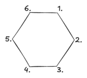

Math terminology and formulas:

- $r$: apothem or inradius (minimal radius)
- $R$: circumradius (maximal radius)
- $a$: side length

$R=a$

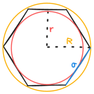

See more details: https://www.gigacalculator.com/calculators/hexagon-calculator.php

**Polygon:**

The recommended svgwrite tool to create this shape is [Polygon](https://svgwrite.readthedocs.io/en/latest/classes/shapes.html#polygon). Before applying points to the polygon shape, round the values into integers `round(Value)`.

Example points for hexagon with 60 inradius and center point (75, 75):

[output not shown]

Apply also fill and stroke colors to the shape.

**Example program runs:**

```
Program starting.
Options:
1 - Draw square
2 - Draw circle
3 - Draw hexagon
4 - Save svg
0 - Exit
Your choice: 3
Insert hexagon details:
Middle point X: 75
Middle point Y: 75
Apothem length: 60
Insert fill: antiquewhite
Insert stroke: gray

Options:
1 - Draw square
2 - Draw circle
3 - Draw hexagon
4 - Save svg
0 - Exit
Your choice: 4
Insert filename: A8_T7_F1.svg
Saving file to "A8_T7_F1.svg"
Proceed (y/n)?: y
Vector saved successfully!

Options:
1 - Draw square
2 - Draw circle
3 - Draw hexagon
4 - Save svg
0 - Exit
Your choice: 0
Exiting program.

Program ending.
```

```
Program starting.
Options:
1 - Draw square
2 - Draw circle
3 - Draw hexagon
4 - Save svg
0 - Exit
Your choice: 3
Insert hexagon details:
Middle point X: 150
Middle point Y: 75
Apothem length: 40
Insert fill: aquamarine
Insert stroke: gray

Options:
1 - Draw square
2 - Draw circle
3 - Draw hexagon
4 - Save svg
0 - Exit
Your choice: 4
Insert filename: A8_T7_F2.svg
Saving file to "A8_T7_F2.svg"
Proceed (y/n)?: y
Vector saved successfully!

Options:
1 - Draw square
2 - Draw circle
3 - Draw hexagon
4 - Save svg
0 - Exit
Your choice: 0
Exiting program.

Program ending.
```

```
Program starting.
Options:
1 - Draw square
2 - Draw circle
3 - Draw hexagon
4 - Save svg
0 - Exit
Your choice: 3
Insert hexagon details:
Middle point X: 225
Middle point Y: 75
Apothem length: 50
Insert fill: coral
Insert stroke: gray

Options:
1 - Draw square
2 - Draw circle
3 - Draw hexagon
4 - Save svg
0 - Exit
Your choice: 4
Insert filename: A8_T7_F3.svg
Saving file to "A8_T7_F3.svg"
Proceed (y/n)?: y
Vector saved successfully!

Options:
1 - Draw square
2 - Draw circle
3 - Draw hexagon
4 - Save svg
0 - Exit
Your choice: 0
Exiting program.

Program ending.
```